Control of Confounding with Stratification

# Control of Confounding with Stratification ...

**Cardiovascular disease** (CVD) is a general term for conditions affecting the heart or blood vessels. There are multiple risk factors for CVD including physical inactivity, tobacco use and alcohol misuse. The risk of CVD also increases with age. Therefore any of these factors may be potential confounders in an analysis, such as that presented below, of the association between obesity (Risk) and CVD (Outcome).

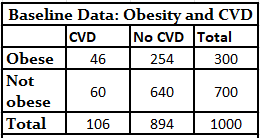

**Table 1.**

#### **Step 1: Find a crude association** ...

- Compute relative risk (RR) and odds ratio (OR) of CVD among those who are and are not exposed
- The outcome is CVD/no CVD, the exposure is obesity/no obesity

#### **Step 2: Identify possible confounders (stratum specific rates)** ...

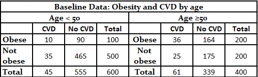

**Table 2.**

Notes:

The risk ratios for the age-stratified analysis are similar, but less then the crude risk ratio (RR=1.79)  
This indicates that there was confounding by age in the overall sample.

### Apply the example to the criteria ...

1. The confounding variable must be associated with the exposure (but not a consequence of the exposure)
   - Obesity is more common in older subjects, meaning that age and obesity are associated
2. The confounding variable must be associated with outcome independently of exposure
   - Older subjects have a higher risk of CVD than younger subjects; this was true for both obese and non-obese subjects.
   - Therefore, age and CVD (the outcome of interest) are associated
3. Age is not an intermediary variable in the causal chain between obesity and CVD. While you may not have a full understanding of this now, on Thursday, when we cover mediation, you will.
   - Therefore, these observations satisfy all three of the requirements for a confounder.

The crude analysis (i.e., without considering the confounder of age) overestimated the true association between obesity and CVD, because of the greater proportion of older subjects among the obese group